# rbmiUtils

[figure not shown]

[figure not shown]

`rbmiUtils` bridges rbmi analysis results into publication-ready regulatory tables and forest plots. It extends rbmi for clinical trial workflows, handling everything from data validation through to formatted efficacy outputs.

## Installation

You can install the package from CRAN or the development version from GitHub:

| Type | Source | Command |
| --- | --- | --- |
| Release | CRAN | `install.packages("rbmiUtils")` |
| Development | GitHub | `remotes::install_github("openpharma/rbmiUtils")` |

## Quick Start

`rbmiUtils` extends the [rbmi](https://insightsengineering.github.io/rbmi/) pipeline from raw data to publication-ready outputs. Here is the complete workflow using the bundled `ADEFF` dataset:

```r
library(rbmiUtils)
library(rbmi)
library(dplyr)

# Load example efficacy dataset and prepare factors
data("ADEFF", package = "rbmiUtils")
ADEFF <- ADEFF |>
  mutate(
    TRT = factor(TRT01P, levels = c("Placebo", "Drug A")),
    USUBJID = factor(USUBJID),
    AVISIT = factor(AVISIT, levels = c("Week 24", "Week 48"))
  )

# Define analysis variables
vars <- set_vars(
  subjid = "USUBJID",
  visit = "AVISIT",
  group = "TRT",
  outcome = "CHG",
  covariates = c("BASE", "STRATA", "REGION")
)

# Configure Bayesian imputation method
method <- method_bayes(
  n_samples = 100,
  control = control_bayes(warmup = 200, thin = 2)
)

# Step 1: Fit imputation model (draws)
dat <- ADEFF |> select(USUBJID, STRATA, REGION, TRT, BASE, CHG, AVISIT)
draws_obj <- draws(data = dat, vars = vars, method = method)

# Step 2: Generate imputed datasets
impute_obj <- impute(
  draws_obj,
  references = c("Placebo" = "Placebo", "Drug A" = "Placebo")
)

# Step 3: Extract stacked imputed data
ADMI <- get_imputed_data(impute_obj)

# Step 4: Analyse each imputed dataset
ana_obj <- analyse_mi_data(data = ADMI, vars = vars, method = method, fun = ancova)

# Step 5: Pool results using Rubin's rules
pool_obj <- pool(ana_obj)

# Publication-ready outputs
efficacy_table(pool_obj, arm_labels = c(ref = "Placebo", alt = "Drug A"))
plot_forest(pool_obj, arm_labels = c(ref = "Placebo", alt = "Drug A"))
```

**Forest Plot**

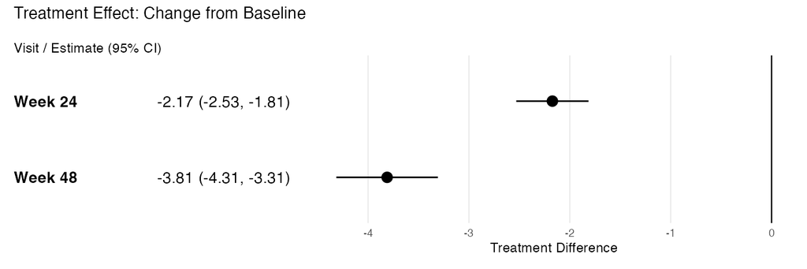

Forest Plot

**Efficacy Table**

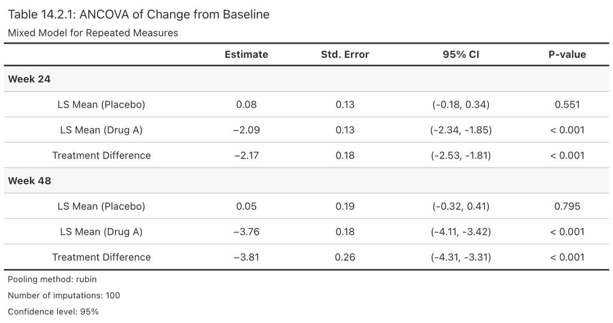

Efficacy Table

See the [end-to-end pipeline vignette](https://openpharma.github.io/rbmiUtils/articles/pipeline.html) for the complete walkthrough from raw data to these outputs.

## Key Features

- `validate_data()` – pre-flight checks on data structure before imputation
- `analyse_mi_data()` – run ANCOVA (or custom analysis) across all imputations
- `tidy_pool_obj()` – tidy pooled results with visit-level annotations
- `efficacy_table()` – regulatory-style gt tables (CDISC/ICH Table 14.2.x format)
- `plot_forest()` – three-panel forest plots with estimates, CIs, and p-values
- `pool_to_ard()` – convert pool objects to pharmaverse ARD format with optional MI diagnostic enrichment (FMI, lambda, RIV)
- `get_imputed_data()` – extract long-format imputed datasets
- `describe_draws()` – inspect draws objects (method, samples, convergence diagnostics)
- `describe_imputation()` – inspect imputation objects (method, M, missingness breakdown)
- `format_pvalue()` / `format_estimate()` – publication-ready formatting

## Learn More

- [From rbmi Analysis to Regulatory Tables](https://openpharma.github.io/rbmiUtils/articles/pipeline.html) – end-to-end walkthrough from raw data to regulatory outputs
- [Storing and Analyzing Imputed Data](https://openpharma.github.io/rbmiUtils/articles/analyse2.html) – focused guide on analysis workflows
- [MI Diagnostics and Describe Helpers](https://openpharma.github.io/rbmiUtils/articles/diagnostics.html) – inspecting draws, imputations, and MI diagnostic statistics
- [Package documentation](https://openpharma.github.io/rbmiUtils/)

## Development Status

This package is experimental and under active development. Feedback and contributions are welcome via [GitHub issues](https://github.com/openpharma/rbmiUtils/issues) or pull requests.